# Risk Factor Analysis

## Outcome Variable

**Outcome Variable:** pers_wast

## Predictor Variables

**Intervention Variable:** nchldlt5

**Adjustment Set:**

unadjusted

## Stratifying Variables

The analysis was stratified on these variable(s):

- agecat
- studyid
- country

## Data Summary

| agecat | studyid | country | nchldlt5 | pers_wast | n_cell | n |
| --- | --- | --- | --- | --- | --- | --- |
| 0-24 months | iLiNS-Zinc | BURKINA FASO | 1 | 0 | 488 | 1639 |
| 0-24 months | iLiNS-Zinc | BURKINA FASO | 1 | 1 | 62 | 1639 |
| 0-24 months | iLiNS-Zinc | BURKINA FASO | 2+ | 0 | 958 | 1639 |
| 0-24 months | iLiNS-Zinc | BURKINA FASO | 2+ | 1 | 131 | 1639 |
| 0-24 months | IRC | INDIA | 1 | 0 | 79 | 410 |
| 0-24 months | IRC | INDIA | 1 | 1 | 10 | 410 |
| 0-24 months | IRC | INDIA | 2+ | 0 | 283 | 410 |
| 0-24 months | IRC | INDIA | 2+ | 1 | 38 | 410 |
| 0-24 months | JiVitA-3 | BANGLADESH | 1 | 0 | 9569 | 15793 |
| 0-24 months | JiVitA-3 | BANGLADESH | 1 | 1 | 596 | 15793 |
| 0-24 months | JiVitA-3 | BANGLADESH | 2+ | 0 | 5327 | 15793 |
| 0-24 months | JiVitA-3 | BANGLADESH | 2+ | 1 | 301 | 15793 |
| 0-24 months | LCNI-5 | MALAWI | 1 | 0 | 337 | 711 |
| 0-24 months | LCNI-5 | MALAWI | 1 | 1 | 4 | 711 |
| 0-24 months | LCNI-5 | MALAWI | 2+ | 0 | 368 | 711 |
| 0-24 months | LCNI-5 | MALAWI | 2+ | 1 | 2 | 711 |
| 0-24 months | NIH-Crypto | BANGLADESH | 1 | 0 | 504 | 730 |
| 0-24 months | NIH-Crypto | BANGLADESH | 1 | 1 | 16 | 730 |
| 0-24 months | NIH-Crypto | BANGLADESH | 2+ | 0 | 200 | 730 |
| 0-24 months | NIH-Crypto | BANGLADESH | 2+ | 1 | 10 | 730 |
| 0-24 months | PROVIDE | BANGLADESH | 1 | 0 | 460 | 641 |
| 0-24 months | PROVIDE | BANGLADESH | 1 | 1 | 10 | 641 |
| 0-24 months | PROVIDE | BANGLADESH | 2+ | 0 | 166 | 641 |
| 0-24 months | PROVIDE | BANGLADESH | 2+ | 1 | 5 | 641 |
| 0-24 months | TanzaniaChild2 | TANZANIA, UNITED REPUBLIC OF | 1 | 0 | 1440 | 2157 |
| 0-24 months | TanzaniaChild2 | TANZANIA, UNITED REPUBLIC OF | 1 | 1 | 38 | 2157 |
| 0-24 months | TanzaniaChild2 | TANZANIA, UNITED REPUBLIC OF | 2+ | 0 | 659 | 2157 |
| 0-24 months | TanzaniaChild2 | TANZANIA, UNITED REPUBLIC OF | 2+ | 1 | 20 | 2157 |
| 0-6 months | IRC | INDIA | 1 | 0 | 69 | 402 |
| 0-6 months | IRC | INDIA | 1 | 1 | 16 | 402 |
| 0-6 months | IRC | INDIA | 2+ | 0 | 269 | 402 |
| 0-6 months | IRC | INDIA | 2+ | 1 | 48 | 402 |
| 0-6 months | JiVitA-3 | BANGLADESH | 1 | 0 | 31 | 50 |
| 0-6 months | JiVitA-3 | BANGLADESH | 1 | 1 | 1 | 50 |
| 0-6 months | JiVitA-3 | BANGLADESH | 2+ | 0 | 17 | 50 |
| 0-6 months | JiVitA-3 | BANGLADESH | 2+ | 1 | 1 | 50 |
| 0-6 months | NIH-Crypto | BANGLADESH | 1 | 0 | 193 | 250 |
| 0-6 months | NIH-Crypto | BANGLADESH | 1 | 1 | 4 | 250 |
| 0-6 months | NIH-Crypto | BANGLADESH | 2+ | 0 | 52 | 250 |
| 0-6 months | NIH-Crypto | BANGLADESH | 2+ | 1 | 1 | 250 |
| 0-6 months | PROVIDE | BANGLADESH | 1 | 0 | 459 | 638 |
| 0-6 months | PROVIDE | BANGLADESH | 1 | 1 | 9 | 638 |
| 0-6 months | PROVIDE | BANGLADESH | 2+ | 0 | 165 | 638 |
| 0-6 months | PROVIDE | BANGLADESH | 2+ | 1 | 5 | 638 |
| 0-6 months | TanzaniaChild2 | TANZANIA, UNITED REPUBLIC OF | 1 | 0 | 1372 | 2053 |
| 0-6 months | TanzaniaChild2 | TANZANIA, UNITED REPUBLIC OF | 1 | 1 | 36 | 2053 |
| 0-6 months | TanzaniaChild2 | TANZANIA, UNITED REPUBLIC OF | 2+ | 0 | 629 | 2053 |
| 0-6 months | TanzaniaChild2 | TANZANIA, UNITED REPUBLIC OF | 2+ | 1 | 16 | 2053 |
| 6-24 months | iLiNS-Zinc | BURKINA FASO | 1 | 0 | 488 | 1639 |
| 6-24 months | iLiNS-Zinc | BURKINA FASO | 1 | 1 | 62 | 1639 |
| 6-24 months | iLiNS-Zinc | BURKINA FASO | 2+ | 0 | 958 | 1639 |
| 6-24 months | iLiNS-Zinc | BURKINA FASO | 2+ | 1 | 131 | 1639 |
| 6-24 months | IRC | INDIA | 1 | 0 | 79 | 410 |
| 6-24 months | IRC | INDIA | 1 | 1 | 10 | 410 |
| 6-24 months | IRC | INDIA | 2+ | 0 | 283 | 410 |
| 6-24 months | IRC | INDIA | 2+ | 1 | 38 | 410 |
| 6-24 months | JiVitA-3 | BANGLADESH | 1 | 0 | 9569 | 15793 |
| 6-24 months | JiVitA-3 | BANGLADESH | 1 | 1 | 596 | 15793 |
| 6-24 months | JiVitA-3 | BANGLADESH | 2+ | 0 | 5327 | 15793 |
| 6-24 months | JiVitA-3 | BANGLADESH | 2+ | 1 | 301 | 15793 |
| 6-24 months | LCNI-5 | MALAWI | 1 | 0 | 337 | 711 |
| 6-24 months | LCNI-5 | MALAWI | 1 | 1 | 4 | 711 |
| 6-24 months | LCNI-5 | MALAWI | 2+ | 0 | 368 | 711 |
| 6-24 months | LCNI-5 | MALAWI | 2+ | 1 | 2 | 711 |
| 6-24 months | NIH-Crypto | BANGLADESH | 1 | 0 | 504 | 730 |
| 6-24 months | NIH-Crypto | BANGLADESH | 1 | 1 | 16 | 730 |
| 6-24 months | NIH-Crypto | BANGLADESH | 2+ | 0 | 200 | 730 |
| 6-24 months | NIH-Crypto | BANGLADESH | 2+ | 1 | 10 | 730 |
| 6-24 months | PROVIDE | BANGLADESH | 1 | 0 | 460 | 641 |
| 6-24 months | PROVIDE | BANGLADESH | 1 | 1 | 10 | 641 |
| 6-24 months | PROVIDE | BANGLADESH | 2+ | 0 | 166 | 641 |
| 6-24 months | PROVIDE | BANGLADESH | 2+ | 1 | 5 | 641 |
| 6-24 months | TanzaniaChild2 | TANZANIA, UNITED REPUBLIC OF | 1 | 0 | 1440 | 2157 |
| 6-24 months | TanzaniaChild2 | TANZANIA, UNITED REPUBLIC OF | 1 | 1 | 38 | 2157 |
| 6-24 months | TanzaniaChild2 | TANZANIA, UNITED REPUBLIC OF | 2+ | 0 | 659 | 2157 |
| 6-24 months | TanzaniaChild2 | TANZANIA, UNITED REPUBLIC OF | 2+ | 1 | 20 | 2157 |

The following strata were considered:

- agecat: 0-24 months, studyid: iLiNS-Zinc, country: BURKINA FASO
- agecat: 0-24 months, studyid: IRC, country: INDIA
- agecat: 0-24 months, studyid: JiVitA-3, country: BANGLADESH
- agecat: 0-24 months, studyid: LCNI-5, country: MALAWI
- agecat: 0-24 months, studyid: NIH-Crypto, country: BANGLADESH
- agecat: 0-24 months, studyid: PROVIDE, country: BANGLADESH
- agecat: 0-24 months, studyid: TanzaniaChild2, country: TANZANIA, UNITED REPUBLIC OF
- agecat: 0-6 months, studyid: IRC, country: INDIA
- agecat: 0-6 months, studyid: JiVitA-3, country: BANGLADESH
- agecat: 0-6 months, studyid: NIH-Crypto, country: BANGLADESH
- agecat: 0-6 months, studyid: PROVIDE, country: BANGLADESH
- agecat: 0-6 months, studyid: TanzaniaChild2, country: TANZANIA, UNITED REPUBLIC OF
- agecat: 6-24 months, studyid: iLiNS-Zinc, country: BURKINA FASO
- agecat: 6-24 months, studyid: IRC, country: INDIA
- agecat: 6-24 months, studyid: JiVitA-3, country: BANGLADESH
- agecat: 6-24 months, studyid: LCNI-5, country: MALAWI
- agecat: 6-24 months, studyid: NIH-Crypto, country: BANGLADESH
- agecat: 6-24 months, studyid: PROVIDE, country: BANGLADESH
- agecat: 6-24 months, studyid: TanzaniaChild2, country: TANZANIA, UNITED REPUBLIC OF

### Dropped Strata

Some strata were dropped due to rare outcomes:

- agecat: 0-24 months, studyid: LCNI-5, country: MALAWI
- agecat: 0-6 months, studyid: JiVitA-3, country: BANGLADESH
- agecat: 0-6 months, studyid: NIH-Crypto, country: BANGLADESH
- agecat: 6-24 months, studyid: LCNI-5, country: MALAWI

## Methods Detail

We’re interested in the causal parameters $E[Y_a]$ for all values of $a \in \mathcal{A}$. These parameters represent the mean outcome if, possibly contrary to fact, we intervened to set all units to have $A=a$. Under the randomization and positivity assumptions, these are identified by the statistical parameters $\psi_a=E_W[E_{Y|A,W}(Y|A=a,W)]$. In addition, we’re interested in the mean of $Y$, $E[Y]$ under no intervention (the observed mean). We will estimate these parameters by using SuperLearner to fit the relevant likelihood factors – $E_{Y|A,W}(Y|A=a,W)$ and $p(A=a|W)$, and then updating our likelihood fit using a joint TMLE.

For unadjusted analyses ($W=\{\}$), initial likelihoods were estimated using Lrnr_glm to estimate the simple $E(Y|A)$ and Lrnr_mean to estimate $p(A)$. For adjusted analyses, a small library containing Lrnr_glmnet, Lrnr_xgboost, and Lrnr_mean was used.

Having estimated these parameters, we will then use the delta method to estimate relative risks and attributable risks relative to a prespecified baseline level of $A$.

# Results Detail

## Results Plots

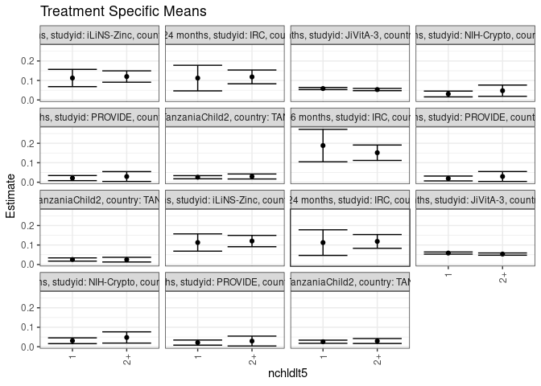

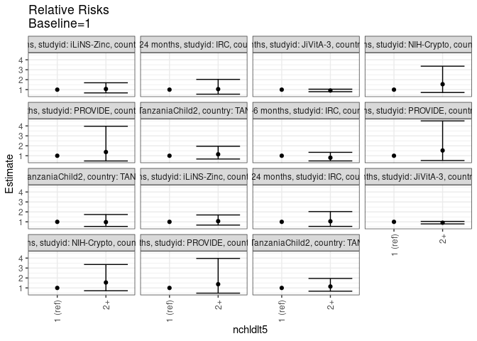

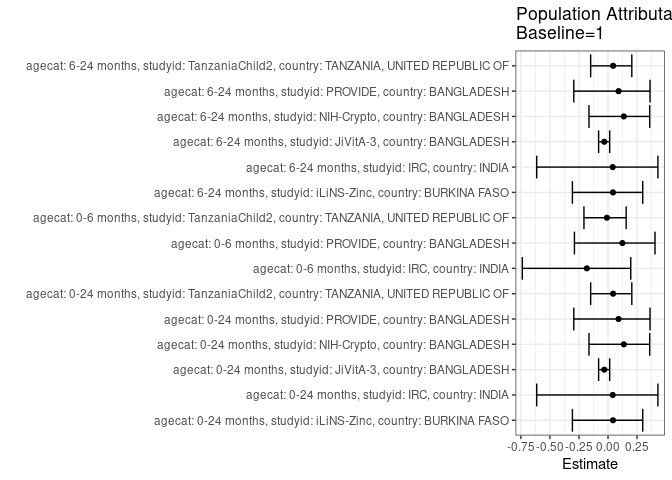

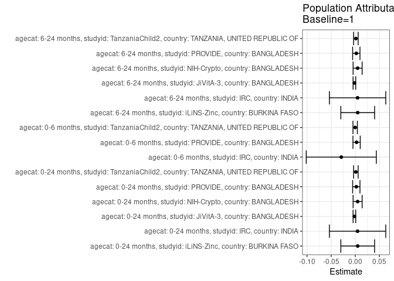

## Results Table

### Parameter: TSM

| agecat | studyid | country | intervention_level | baseline_level | estimate | ci_lower | ci_upper |
| --- | --- | --- | --- | --- | --- | --- | --- |
| 0-24 months | iLiNS-Zinc | BURKINA FASO | 1 | NA | 0.1127273 | 0.0684688 | 0.1569857 |
| 0-24 months | iLiNS-Zinc | BURKINA FASO | 2+ | NA | 0.1202938 | 0.0911517 | 0.1494360 |
| 0-24 months | IRC | INDIA | 1 | NA | 0.1123596 | 0.0466684 | 0.1780507 |
| 0-24 months | IRC | INDIA | 2+ | NA | 0.1183801 | 0.0829962 | 0.1537640 |
| 0-24 months | JiVitA-3 | BANGLADESH | 1 | NA | 0.0586326 | 0.0532285 | 0.0640367 |
| 0-24 months | JiVitA-3 | BANGLADESH | 2+ | NA | 0.0534826 | 0.0477628 | 0.0592023 |
| 0-24 months | NIH-Crypto | BANGLADESH | 1 | NA | 0.0307692 | 0.0159162 | 0.0456223 |
| 0-24 months | NIH-Crypto | BANGLADESH | 2+ | NA | 0.0476190 | 0.0187965 | 0.0764416 |
| 0-24 months | PROVIDE | BANGLADESH | 1 | NA | 0.0212766 | 0.0082203 | 0.0343329 |
| 0-24 months | PROVIDE | BANGLADESH | 2+ | NA | 0.0292398 | 0.0039682 | 0.0545113 |
| 0-24 months | TanzaniaChild2 | TANZANIA, UNITED REPUBLIC OF | 1 | NA | 0.0257104 | 0.0176397 | 0.0337811 |
| 0-24 months | TanzaniaChild2 | TANZANIA, UNITED REPUBLIC OF | 2+ | NA | 0.0294551 | 0.0167346 | 0.0421755 |
| 0-6 months | IRC | INDIA | 1 | NA | 0.1882353 | 0.1050311 | 0.2714395 |
| 0-6 months | IRC | INDIA | 2+ | NA | 0.1514196 | 0.1119105 | 0.1909286 |
| 0-6 months | PROVIDE | BANGLADESH | 1 | NA | 0.0192308 | 0.0067785 | 0.0316830 |
| 0-6 months | PROVIDE | BANGLADESH | 2+ | NA | 0.0294118 | 0.0039937 | 0.0548298 |
| 0-6 months | TanzaniaChild2 | TANZANIA, UNITED REPUBLIC OF | 1 | NA | 0.0255682 | 0.0173215 | 0.0338148 |
| 0-6 months | TanzaniaChild2 | TANZANIA, UNITED REPUBLIC OF | 2+ | NA | 0.0248062 | 0.0128002 | 0.0368122 |
| 6-24 months | iLiNS-Zinc | BURKINA FASO | 1 | NA | 0.1127273 | 0.0684688 | 0.1569857 |
| 6-24 months | iLiNS-Zinc | BURKINA FASO | 2+ | NA | 0.1202938 | 0.0911517 | 0.1494360 |
| 6-24 months | IRC | INDIA | 1 | NA | 0.1123596 | 0.0466684 | 0.1780507 |
| 6-24 months | IRC | INDIA | 2+ | NA | 0.1183801 | 0.0829962 | 0.1537640 |
| 6-24 months | JiVitA-3 | BANGLADESH | 1 | NA | 0.0586326 | 0.0532285 | 0.0640367 |
| 6-24 months | JiVitA-3 | BANGLADESH | 2+ | NA | 0.0534826 | 0.0477628 | 0.0592023 |
| 6-24 months | NIH-Crypto | BANGLADESH | 1 | NA | 0.0307692 | 0.0159162 | 0.0456223 |
| 6-24 months | NIH-Crypto | BANGLADESH | 2+ | NA | 0.0476190 | 0.0187965 | 0.0764416 |
| 6-24 months | PROVIDE | BANGLADESH | 1 | NA | 0.0212766 | 0.0082203 | 0.0343329 |
| 6-24 months | PROVIDE | BANGLADESH | 2+ | NA | 0.0292398 | 0.0039682 | 0.0545113 |
| 6-24 months | TanzaniaChild2 | TANZANIA, UNITED REPUBLIC OF | 1 | NA | 0.0257104 | 0.0176397 | 0.0337811 |
| 6-24 months | TanzaniaChild2 | TANZANIA, UNITED REPUBLIC OF | 2+ | NA | 0.0294551 | 0.0167346 | 0.0421755 |

### Parameter: E(Y)

| agecat | studyid | country | intervention_level | baseline_level | estimate | ci_lower | ci_upper |
| --- | --- | --- | --- | --- | --- | --- | --- |
| 0-24 months | iLiNS-Zinc | BURKINA FASO | NA | NA | 0.1177547 | 0.0931926 | 0.1423168 |
| 0-24 months | IRC | INDIA | NA | NA | 0.1170732 | 0.0859146 | 0.1482317 |
| 0-24 months | JiVitA-3 | BANGLADESH | NA | NA | 0.0567973 | 0.0526805 | 0.0609141 |
| 0-24 months | NIH-Crypto | BANGLADESH | NA | NA | 0.0356164 | 0.0221630 | 0.0490699 |
| 0-24 months | PROVIDE | BANGLADESH | NA | NA | 0.0234009 | 0.0116889 | 0.0351130 |
| 0-24 months | TanzaniaChild2 | TANZANIA, UNITED REPUBLIC OF | NA | NA | 0.0268892 | 0.0200612 | 0.0337172 |
| 0-6 months | IRC | INDIA | NA | NA | 0.1592040 | 0.1233945 | 0.1950135 |
| 0-6 months | PROVIDE | BANGLADESH | NA | NA | 0.0219436 | 0.0105669 | 0.0333202 |
| 0-6 months | TanzaniaChild2 | TANZANIA, UNITED REPUBLIC OF | NA | NA | 0.0253288 | 0.0185306 | 0.0321270 |
| 6-24 months | iLiNS-Zinc | BURKINA FASO | NA | NA | 0.1177547 | 0.0931926 | 0.1423168 |
| 6-24 months | IRC | INDIA | NA | NA | 0.1170732 | 0.0859146 | 0.1482317 |
| 6-24 months | JiVitA-3 | BANGLADESH | NA | NA | 0.0567973 | 0.0526805 | 0.0609141 |
| 6-24 months | NIH-Crypto | BANGLADESH | NA | NA | 0.0356164 | 0.0221630 | 0.0490699 |
| 6-24 months | PROVIDE | BANGLADESH | NA | NA | 0.0234009 | 0.0116889 | 0.0351130 |
| 6-24 months | TanzaniaChild2 | TANZANIA, UNITED REPUBLIC OF | NA | NA | 0.0268892 | 0.0200612 | 0.0337172 |

### Parameter: RR

| agecat | studyid | country | intervention_level | baseline_level | estimate | ci_lower | ci_upper |
| --- | --- | --- | --- | --- | --- | --- | --- |
| 0-24 months | iLiNS-Zinc | BURKINA FASO | 1 | 1 | 1.0000000 | 1.0000000 | 1.000000 |
| 0-24 months | iLiNS-Zinc | BURKINA FASO | 2+ | 1 | 1.0671228 | 0.6728384 | 1.692459 |
| 0-24 months | IRC | INDIA | 1 | 1 | 1.0000000 | 1.0000000 | 1.000000 |
| 0-24 months | IRC | INDIA | 2+ | 1 | 1.0535826 | 0.5463855 | 2.031599 |
| 0-24 months | JiVitA-3 | BANGLADESH | 1 | 1 | 1.0000000 | 1.0000000 | 1.000000 |
| 0-24 months | JiVitA-3 | BANGLADESH | 2+ | 1 | 0.9121653 | 0.7947657 | 1.046907 |
| 0-24 months | NIH-Crypto | BANGLADESH | 1 | 1 | 1.0000000 | 1.0000000 | 1.000000 |
| 0-24 months | NIH-Crypto | BANGLADESH | 2+ | 1 | 1.5476190 | 0.7135681 | 3.356547 |
| 0-24 months | PROVIDE | BANGLADESH | 1 | 1 | 1.0000000 | 1.0000000 | 1.000000 |
| 0-24 months | PROVIDE | BANGLADESH | 2+ | 1 | 1.3742690 | 0.4761342 | 3.966561 |
| 0-24 months | TanzaniaChild2 | TANZANIA, UNITED REPUBLIC OF | 1 | 1 | 1.0000000 | 1.0000000 | 1.000000 |
| 0-24 months | TanzaniaChild2 | TANZANIA, UNITED REPUBLIC OF | 2+ | 1 | 1.1456476 | 0.6717152 | 1.953966 |
| 0-6 months | IRC | INDIA | 1 | 1 | 1.0000000 | 1.0000000 | 1.000000 |
| 0-6 months | IRC | INDIA | 2+ | 1 | 0.8044164 | 0.4814626 | 1.344000 |
| 0-6 months | PROVIDE | BANGLADESH | 1 | 1 | 1.0000000 | 1.0000000 | 1.000000 |
| 0-6 months | PROVIDE | BANGLADESH | 2+ | 1 | 1.5294118 | 0.5194431 | 4.503092 |
| 0-6 months | TanzaniaChild2 | TANZANIA, UNITED REPUBLIC OF | 1 | 1 | 1.0000000 | 1.0000000 | 1.000000 |
| 0-6 months | TanzaniaChild2 | TANZANIA, UNITED REPUBLIC OF | 2+ | 1 | 0.9701981 | 0.5423343 | 1.735616 |
| 6-24 months | iLiNS-Zinc | BURKINA FASO | 1 | 1 | 1.0000000 | 1.0000000 | 1.000000 |
| 6-24 months | iLiNS-Zinc | BURKINA FASO | 2+ | 1 | 1.0671228 | 0.6728384 | 1.692459 |
| 6-24 months | IRC | INDIA | 1 | 1 | 1.0000000 | 1.0000000 | 1.000000 |
| 6-24 months | IRC | INDIA | 2+ | 1 | 1.0535826 | 0.5463855 | 2.031599 |
| 6-24 months | JiVitA-3 | BANGLADESH | 1 | 1 | 1.0000000 | 1.0000000 | 1.000000 |
| 6-24 months | JiVitA-3 | BANGLADESH | 2+ | 1 | 0.9121653 | 0.7947657 | 1.046907 |
| 6-24 months | NIH-Crypto | BANGLADESH | 1 | 1 | 1.0000000 | 1.0000000 | 1.000000 |
| 6-24 months | NIH-Crypto | BANGLADESH | 2+ | 1 | 1.5476190 | 0.7135681 | 3.356547 |
| 6-24 months | PROVIDE | BANGLADESH | 1 | 1 | 1.0000000 | 1.0000000 | 1.000000 |
| 6-24 months | PROVIDE | BANGLADESH | 2+ | 1 | 1.3742690 | 0.4761342 | 3.966561 |
| 6-24 months | TanzaniaChild2 | TANZANIA, UNITED REPUBLIC OF | 1 | 1 | 1.0000000 | 1.0000000 | 1.000000 |
| 6-24 months | TanzaniaChild2 | TANZANIA, UNITED REPUBLIC OF | 2+ | 1 | 1.1456476 | 0.6717152 | 1.953966 |

### Parameter: PAR

| agecat | studyid | country | intervention_level | baseline_level | estimate | ci_lower | ci_upper |
| --- | --- | --- | --- | --- | --- | --- | --- |
| 0-24 months | iLiNS-Zinc | BURKINA FASO | 1 | NA | 0.0050275 | -0.0299461 | 0.0400010 |
| 0-24 months | IRC | INDIA | 1 | NA | 0.0047136 | -0.0537047 | 0.0631319 |
| 0-24 months | JiVitA-3 | BANGLADESH | 1 | NA | -0.0018352 | -0.0045691 | 0.0008986 |
| 0-24 months | NIH-Crypto | BANGLADESH | 1 | NA | 0.0048472 | -0.0044968 | 0.0141912 |
| 0-24 months | PROVIDE | BANGLADESH | 1 | NA | 0.0021243 | -0.0054689 | 0.0097175 |
| 0-24 months | TanzaniaChild2 | TANZANIA, UNITED REPUBLIC OF | 1 | NA | 0.0011788 | -0.0035640 | 0.0059216 |
| 0-6 months | IRC | INDIA | 1 | NA | -0.0290313 | -0.1016787 | 0.0436161 |
| 0-6 months | PROVIDE | BANGLADESH | 1 | NA | 0.0027128 | -0.0048372 | 0.0102628 |
| 0-6 months | TanzaniaChild2 | TANZANIA, UNITED REPUBLIC OF | 1 | NA | -0.0002394 | -0.0048155 | 0.0043367 |
| 6-24 months | iLiNS-Zinc | BURKINA FASO | 1 | NA | 0.0050275 | -0.0299461 | 0.0400010 |
| 6-24 months | IRC | INDIA | 1 | NA | 0.0047136 | -0.0537047 | 0.0631319 |
| 6-24 months | JiVitA-3 | BANGLADESH | 1 | NA | -0.0018352 | -0.0045691 | 0.0008986 |
| 6-24 months | NIH-Crypto | BANGLADESH | 1 | NA | 0.0048472 | -0.0044968 | 0.0141912 |
| 6-24 months | PROVIDE | BANGLADESH | 1 | NA | 0.0021243 | -0.0054689 | 0.0097175 |
| 6-24 months | TanzaniaChild2 | TANZANIA, UNITED REPUBLIC OF | 1 | NA | 0.0011788 | -0.0035640 | 0.0059216 |

### Parameter: PAF

| agecat | studyid | country | intervention_level | baseline_level | estimate | ci_lower | ci_upper |
| --- | --- | --- | --- | --- | --- | --- | --- |
| 0-24 months | iLiNS-Zinc | BURKINA FASO | 1 | NA | 0.0426943 | -0.3066569 | 0.2986421 |
| 0-24 months | IRC | INDIA | 1 | NA | 0.0402622 | -0.6140371 | 0.4293212 |
| 0-24 months | JiVitA-3 | BANGLADESH | 1 | NA | -0.0323122 | -0.0811223 | 0.0142942 |
| 0-24 months | NIH-Crypto | BANGLADESH | 1 | NA | 0.1360947 | -0.1640215 | 0.3588328 |
| 0-24 months | PROVIDE | BANGLADESH | 1 | NA | 0.0907801 | -0.2947917 | 0.3615338 |
| 0-24 months | TanzaniaChild2 | TANZANIA, UNITED REPUBLIC OF | 1 | NA | 0.0438384 | -0.1494600 | 0.2046308 |
| 0-6 months | IRC | INDIA | 1 | NA | -0.1823529 | -0.7377372 | 0.1955294 |
| 0-6 months | PROVIDE | BANGLADESH | 1 | NA | 0.1236264 | -0.2892206 | 0.4042674 |
| 0-6 months | TanzaniaChild2 | TANZANIA, UNITED REPUBLIC OF | 1 | NA | -0.0094515 | -0.2072770 | 0.1559581 |
| 6-24 months | iLiNS-Zinc | BURKINA FASO | 1 | NA | 0.0426943 | -0.3066569 | 0.2986421 |
| 6-24 months | IRC | INDIA | 1 | NA | 0.0402622 | -0.6140371 | 0.4293212 |
| 6-24 months | JiVitA-3 | BANGLADESH | 1 | NA | -0.0323122 | -0.0811223 | 0.0142942 |
| 6-24 months | NIH-Crypto | BANGLADESH | 1 | NA | 0.1360947 | -0.1640215 | 0.3588328 |
| 6-24 months | PROVIDE | BANGLADESH | 1 | NA | 0.0907801 | -0.2947917 | 0.3615338 |
| 6-24 months | TanzaniaChild2 | TANZANIA, UNITED REPUBLIC OF | 1 | NA | 0.0438384 | -0.1494600 | 0.2046308 |